# Система контроля версий Git

Лабораторная работа №2

Никифоров Захар Сергеевич

1032253520@rudn.ru

Российский университет дружбы народов

2026-03-06

# Вводная часть

## Актуальность

- Система контроля версий необходима для совместной работы над проектами.
- Git — наиболее распространенная система
- Умение работать с Git и GitHub обязательно для современного разработчика

## Объект и предмет исследования

- Объект исследования: система контроля версий Git.
- Предмет исследования: настройка Git, создание ключей GPG и SSH, работа с GitHub.

## Цели и задачи

Цель: Изучить идеологию и применение средств контроля версий. Освоить умения по работе с git.

Задачи: 1. Создать базовую конфигурацию для работы с системой. 2. Создать ключи GPG и SSH. 3. Настройка подписей Git. 4. Создать репозиторий курса на основе шаблона.

## Материалы и методы

- Оборудование: ПК с ОС на базе Linux или ВМ на нем с такой системой
- ПО: Git, GitHub CLI, OpenSSH, GnuPG
- Методы: Установка согласно руководству, настройка через терминал, создание ключей, работа с удаленным репозиторием.

# Выполнение лабораторной работы

## Установление программного обеспечения

- Установлены git и gh.

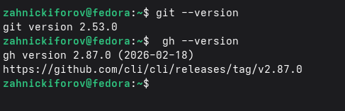

Рисунок 1: Скриншот терминала 1

## Базовая настройка git

- Задаем имя и электронную почту пользователя
- Задаем начальные настройки ветки и ее саму.

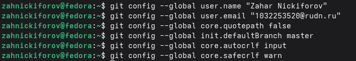

Рисунок 2: Скриншот терминала 2

## Создание ключей SSH и GPG

- Создаем SSH и GPG ключи
- Добавляем их в свой профиль на GitHub.

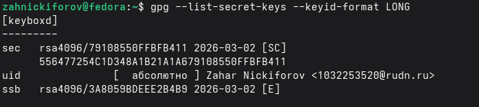

Рисунок 3: Скриншот терминала 3

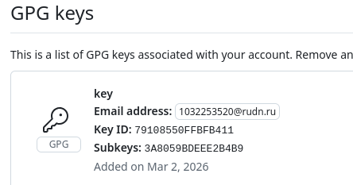

Рисунок 4: GPG ключ

## Настройка автоматических подписей коммитов git

- Настраиваем автоматическую подпись коммитов с помощью нового ключа.

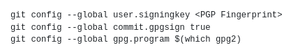

Рисунок 5: Команды для настройки

## Создание репозитория курса на основе шаблона

- Создаем репозиторий курсана основе шаблона для студентво
- Проверяем корректность сборки на GitHub.

[figure not shown]

Рисунок 6: Скриншот страницы на GitHub

# Выводы

- Была изучена идеология и применение средств контроля версий.
- Освоены умения по работе с git.